# Driving Factors behind University Selection

2022-08-27

## Driving Factors behind University Selection

Dataset source: https://www.studyinaustralia.gov.au/English/Australian-Education/Universities-Higher-Education/University-rankings

```r
library(readxl)
HE <- read.csv("HE Rankings updated.csv")
```

### Introduction

Tertiary international students are one of the major contributors to Australia and New Zealand national economy. Especially that Australia is a country which celebrates cultural diversity with 30% immigration population (Australian Bureau of Statistics 2022). It is reported that the source of more than half of the revenue of the University and Sydney and the University of NSW is gained from international students (McGowan 2018). Aside from financial gain, further benefits for Australia and New Zealand include accelerated regional development, created job opportunities and skilled immigrants with tertiary education. Unfortunately, due to Covid-19 pandemic and its related restrictions, this financial source has decreased substantially in the past three years (The University of Sydney 2020). Presence is a time for national post-pandemic rehabilitation. There is an urgent need to attract back international students. Systematic research has been conducted on the reasons behind university choice of international students (Mazzarol & Soutar 2002). However, studies focusing on pacific countries are lacking. This report collects and analyzes data regarding international students enrollment into Australia and New Zealand universities. The first part overlooks the situation of international student enrollment in general using Five Number Summary on university student enrollment rates in both countries as a whole. The second part proceeds to investigate the correlation and possible causation between enrollment rate and several potential driving factors, such as university ranking.

### International Student University Enrollment Overview

The total international student enrollment number in Australia and New Zealand is described using five-number summary and visualized with boxplot. The information of universities with lowest and highest enrollments are separately displayed.

```r
enrollment=HE$Uni.enrolment
summary(enrollment)
```

```
##    Min. 1st Qu.  Median    Mean 3rd Qu.    Max.
##    2695   22807   32948   33938   45580   64479
```

```r
HE[HE$Uni.enrolment==min(enrollment),]
```

```
##   World.Ranking    University.Name     Country International.Student.Ranking
## 9           356 Lincoln University New Zealand                            43
##   Population.of.host.city Uni.enrolment
## 9                  624200          2695
```

```r
HE[HE$Uni.enrolment==max(enrollment),]
```

```
##   World.Ranking   University.Name   Country International.Student.Ranking
## 4            58 Monash University Australia                            27
##   Population.of.host.city Uni.enrolment
## 4           5.078 million         64479
```

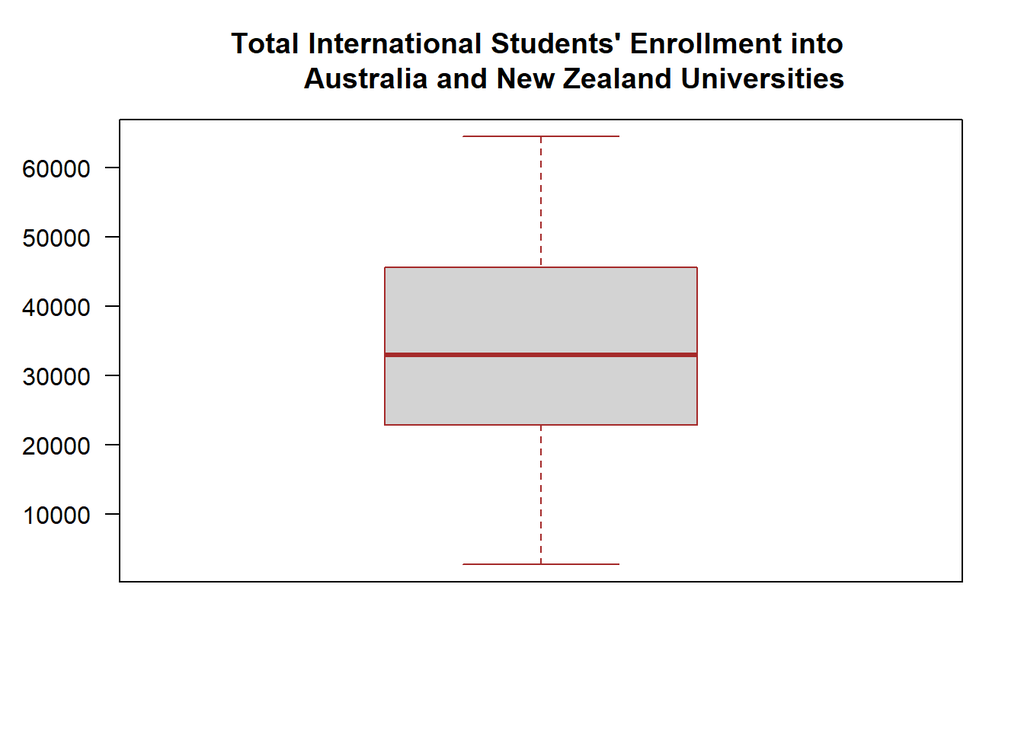

```r
boxplot(enrollment,
        main="Total International Students' Enrollment into
        Australia and New Zealand Universities",
        at = c(1),
        names = c("Enrollment"),
        las = 1,
        border = "brown",
        horizontal = FALSE,
        notch = FALSE
)
```

### Evaluating Driving Factors

The primary purpose of this section is to find connections between admission numbers and likely influential factors, including nation, university QR ranking and International Student Ranking. Possible correlation amongst these factors themselves are also explored.

#### Nation

```r
country=HE$Country
```

```r
c_enroll <- c(sum(HE[which(HE$Country=="Australia"),"Uni.enrolment"]),sum(HE[which(HE$Country=="New Zealand"),"Uni.enrolment"]))
```

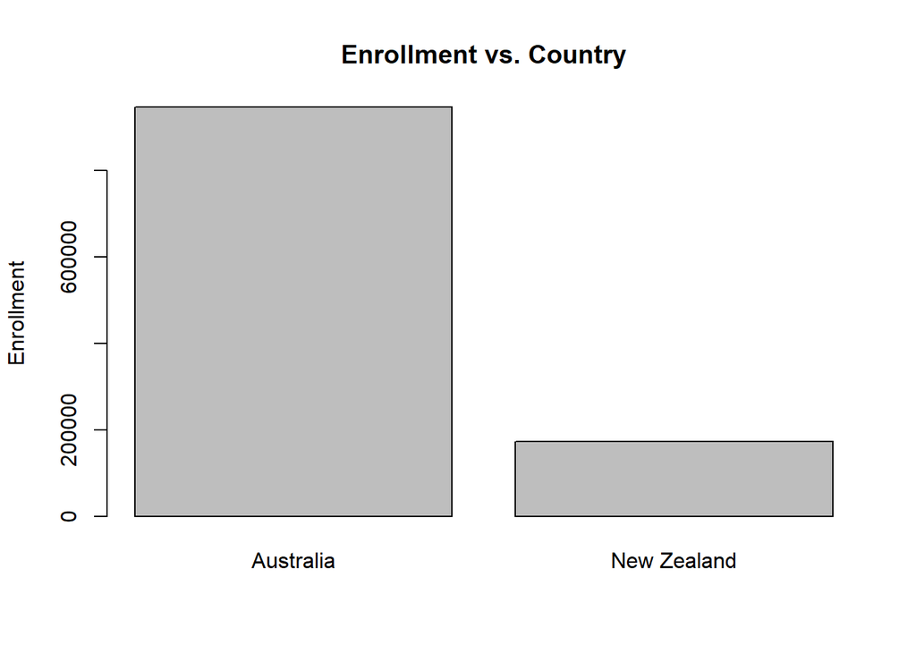

```r
options(scipen=999)
barplot(c_enroll,
        names.arg = c("Australia","New Zealand"),
        main="Enrollment vs. Country",
        ylab="Enrollment",)
```

The tertiary student enrollments in Australia and New Zealand are calculated and compared using a bar graph. Noticeably, the enrollment number in Australia is several times higher than that in New Zealand. Country can be therefore considered as a strong driving factor behind international students’ choice on university.

#### Ranking: QR World Ranking vs. International Student Ranking

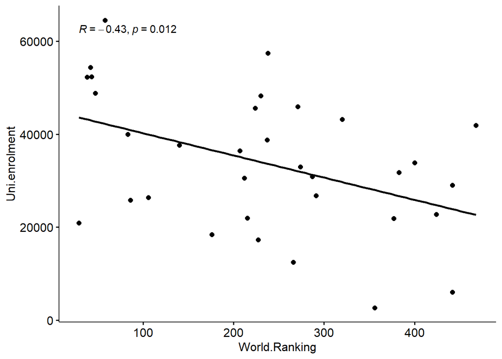

```r
library(ggpubr)
ggscatter(HE,x="World.Ranking",y="Uni.enrolment",add = "reg.line",cor.coef = TRUE)
```

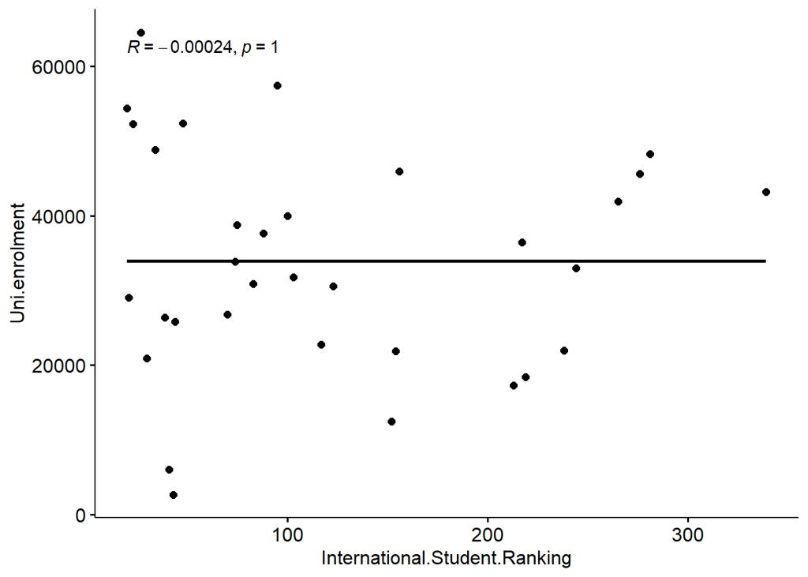

```r
ggscatter(HE,x="International.Student.Ranking",y="Uni.enrolment",add = "reg.line",cor.coef = TRUE)
```

The QR World Ranking and International Student Ranking are tested in their correlation with enrollment rate. As demonstrated in the graphs, the QR ranking as a negative 0.43 correlation, which means the lower the ranking (larger the number), the fewer the enrollments. However, the International Student Ranking and enrollment do not show any correlation, indicated by a coefficient of -0.00024. In one sentence, the QR Ranking is successful in predicting international student university choice while the International Student Ranking is not. This difference could be contributed to low popularity and awareness of the International Student Ranking.

#### country vs. ranking

It is suspected that there is a causal relationship between education quality (university ranking) and country selection. Higher ranking could drive more students to choose this country. Since in last section it was shown that only QR ranking has prediction power, it is used to test correlation between ranking and country. Because it was calculated that Australia attracts more international student, it is predicted to reside more universities with higher QR World ranking.

university number in each country 33 uni, 8 new, 25 aus

```r
c1=which(country=='Australia')
c2=which(country=='New Zealand')
aus=HE[c1,]
nz=HE[c2,]
aus_rank=aus$World.Ranking
nz_rank=nz$World.Ranking
```

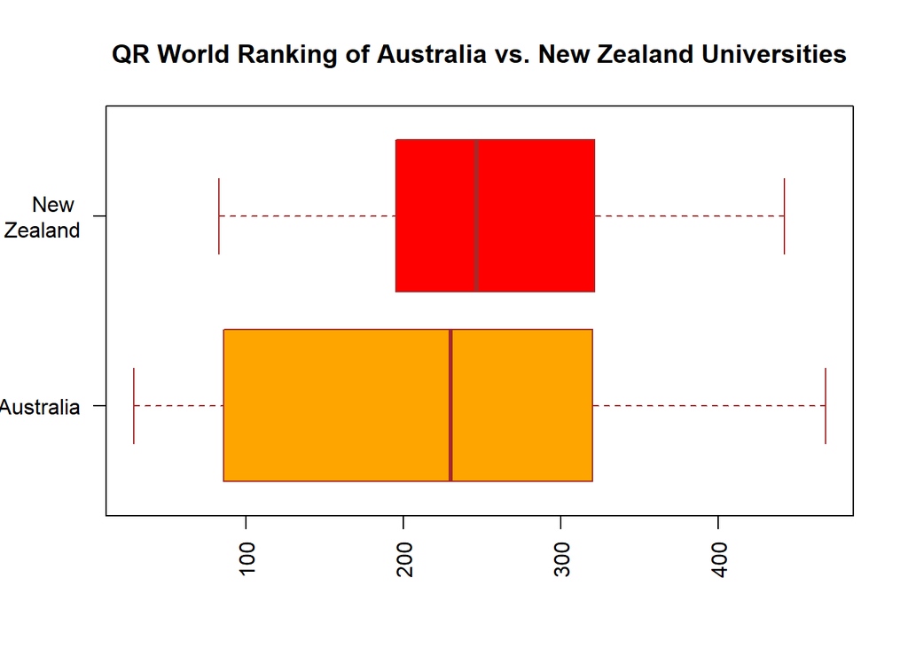

```r
boxplot(aus_rank,nz_rank,
        main="QR World Ranking of Australia vs. New Zealand Universities",
        at = c(1,2),
        names = c("Australia", "New
                  Zealand"),
        las = 2,
        col = c("orange","red"),
        border = "brown",
        horizontal = TRUE,
        notch = FALSE
)
```

A side by side boxplot is chosen to present the difference in university rankings between two countries. The result matches previous prediction that Australia universities have higher QR ranking, as the minimum and first quartile of Australia universities are much higher than those of New Zealand universities. This could be one of the explanations as to why Australia is favored by more international university students.

### Conclusion

The analysis on data supports that both destination country and QR World ranking are strong driving factors behind internaitonal tertiary students’ choice on university, while the International Student ranking is not as relevant, possibly due to low awareness and reputation. Therefore, countries that attracted large amount of international students previous to the Covid-19 pandemic are likely to remain their advantage and gain back the lost students. At the mean time, universities that achieve higher education quality and are able to obtain higher ranking on world-renowned university ranking systems can also gain more favoring among international students.

### References

Australian Bureau of Statistics 2022, Australia’s overseas-born population drops during pandemic, ABS, viewed 20 September 2022, https://www.abs.gov.au/media-centre/media-releases/australias-overseas-born-population-drops-during-pandemic.

Hipkins, HC 2018, International education contributes $5.1 billion to New Zealand economy,Beehive.govt.nz,viewed 20 September 2022, https://www.beehive.govt.nz/release/international-education-contributes-51-billion-new-zealand-economy#:\~:text=%E2%80%9C%244.8%20billion%20is%20attributed%20to,only%20nationally%20but%20also%20regionally..

Mazzarol, T & Soutar, GN 2002, “Push‐pull” factors influencing international student destination choice, International Journal of Educational Management, vol. 16, no. 2, pp. 82-90, https://doi.org/10.1108/09513540210418403.

McGowan, M 2018, Australian universities slip in world rankings amid funding cuts, The Guardian, viewed 20 September 2022, https://www.theguardian.com/australia-news/2018/jun/09/universities-rely-too-much-on-foreign-student-fees-auditor-says.

Statista 2022, Export income from international education activity in Australia from financial years 2013 to 2019, viewed 20 September 2022, https://www.statista.com/statistics/977688/australia-export-income-from-international-education-services/#:\~:text=From%202013%20to%202019%20the,billion%20Australian%20dollars%20in%202019.

The University of Sydney 2020, How universities came to rely on international students, viewed 20 September 2022, https://www.sydney.edu.au/news-opinion/news/2020/05/25/how-universities-came-to-rely-on-international-students.html.